# **Trabalho de Extração de Conhecimento de Dados Biológicos**

#### **Grupo 1** - Ângela Sousa (*PG42489*), Luís Babo (*PG58817*) & Rúben Fernandes (*PG58818*)

Para a realização do trabalho da Unidade Curricular de Extração de Conhecimento de Dados Biológicos de 25/26, escolheu-se um conjunto de dados de expressão genética de leucemia mieloide aguda (AML) disponíveis na plataforma cBioPortal sob o nome “Acute Myeloid Leukemia (OHSU, Nature 2018)”.

## **Origem dos Dados e a sua Relevância**

Este conjunto inclui dados de expressão genética e informação clínica associada aos pacientes.

A leucemia mieloide aguda é um tipo agressivo de cancro, sendo assim relevante estudar padrões de expressão genética para identificar genes diferencialmente expressos e possíveis biomarcadores.

A integração de dados clínicos com expressão génica permite análises mais completas e biologicamente relevantes.

## **Preparação e Pré-processamento dos Dados**

Iniciou-se a análise com a importação do dataset. Durante a importação em si, realizou-se a transposição da matriz de maneira a que a que as colunas correspondem-se às variáveis (genes) e as linhas às amostras (pacientes), garantindo assim a estrutura de dados adequada para futura análise estatística.

Posteriormente, foi necessário corrigir os nomes das colunas com a função colnames(), utilizando a primeira linha do dataset como cabeçalho das variáveis, sendo esta linha removida após essa operação.

De seguida, avaliou-se a presença de valores em falta (NA), confirmando-se a ausência dos mesmos no dataset.

Também se importou o ficheiro com os metadados dos pacientes para auxilixar em análises supervisionadas.

Após este processo, obteve-se um conjunto de dados mais relevante e adequado para a análise de expressão diferencial. Por fim, confirmou-se a consistência dos dados e a correta organização das variáveis, garantindo a correta preparação do dataset para as análises subsequentes.

```r
#library(cbioportalR)
#library(dplyr)
#set_cbioportal_db(db = "public")
library(dplyr)
```

```r
library(tibble)
library(limma)
library(ggplot2)
```

```r
#available_clinical_attributes(study_id = "aml_ohsu_2018")
#available_patients(study_id = "aml_ohsu_2018")
# Iremos completar o upload através do package cbioportalR assim que soubermos como obter dados que queremos em específico
# Alternativamente, fizemos o upload através do import do RStudio

data_zscores <- as.data.frame(t(read.delim("./aml_ohsu_2018/data_mrna_seq_cpm_zscores_ref_all_samples.txt")))

colnames(data_zscores) <- as.character(unlist(data_zscores[1,]))
data_zscores <- data_zscores[-1, ]
data_zscores <- data_zscores[-1, ]

view(data_zscores)
```

```r
any(is.na(data_zscores))
```

```
## [1] FALSE
```

```r
patient_info <- as.data.frame(read.delim("./aml_ohsu_2018/data_clinical_patient.txt", skip = 4, header = T))
view(patient_info)
```

## **Sumarização dos Dados**

Foi realizada uma análise estatística descritiva das variáveis clínicas presentes no conjunto de dados. Relativamente às variáveis numéricas, a idade ao diagnóstico (**AGE_AT_DIAGNOSIS**) apresenta uma mediana de 61 anos (média de 57,5), variando entre 1 e 87 anos. O tempo de sobrevivência (**OS_MONTHS**) apresenta maior variabilidade, com mediana de aproximadamente 10 meses e valores que podem atingir até cerca de 174 meses, embora com um número considerável de valores em falta.

No que diz respeito às variáveis categóricas, na variável **SEX** observa-se uma ligeira predominância do sexo masculino (311 vs 251). A maioria dos doentes pertence ao grupo étnico (**ETHNICITY**) *White*, representando a grande maioria da amostra. A maior parte dos indivíduos foi diagnosticada com Leucemia Mieloide Aguda (AML), sendo esta a categoria dominante nas variáveis de diagnóstico(**DIAGNOSIS**, **DIAGNOSIS_AT_INCLUSION**). Em termos de tratamento (**TREATMENT_TYPE**), a quimioterapia padrão é a abordagem mais frequente, muitas vezes combinada com transplante de medula óssea ou outras terapias. Relativamente ao estado de sobrevivência (**OS_STATUS**), verifica-se um maior número de doentes falecidos (290) em comparação com os vivos (215), refletindo a gravidade da doença. A principal causa de morte (**CAUSE_OF_DEATH_SOURCE**) está associada à progressão da doença.

De forma geral, os dados evidenciam uma população maioritariamente adulta, com elevada heterogeneidade clínica e predominância de AML, sendo possível observar padrões relevantes que justificam análises mais aprofundadas, como a expressão diferencial.

```r
sapply(patient_info[, sapply(patient_info, is.numeric)], summary)
```

```
## $AGE_AT_DIAGNOSIS
##    Min. 1st Qu.  Median    Mean 3rd Qu.    Max.    NA's
##     1.0    48.0    61.0    57.5    71.0    87.0       6
##
## $OS_MONTHS
##    Min. 1st Qu.  Median    Mean 3rd Qu.    Max.    NA's
##    0.03    5.16   10.16   14.17   17.57  174.51      65
##
## $CENTER
##    Min. 1st Qu.  Median    Mean 3rd Qu.    Max.
##   1.000   1.000   2.000   2.379   3.000   7.000
```

```r
char_cols <- sapply(patient_info[, -1], is.character)

sapply(patient_info[, -1][, char_cols], table)
```

```
## $SEX
##
## Female   Male
##    251    311
##
## $ETHNICITY
##
## AdmixedAsian AdmixedBlack AdmixedWhite        Asian        Black   HispNative
##            1            3            1           14           22           52
##        White
##          469
##
## $MDSMPN_DIAGNOSIS_AT_ACQUISITION
##
## False  True
##   542    20
##
## $NON_AML_MDSMPN_DIAGNOSIS_AT_ACQUISITION
##
## False  True
##   558     4
##
## $PRIOR_CANCER
##
##                                                          Adenocarcinoma
##                                 488                                   1
##        Anal carcinoma|Breast Cancer              Anaplastic Astrocytoma
##                                   1                                   1
##                Basal Cell Carcinoma                      Bladder Cancer
##                                   1                                   3
##       Bladder Cancer|Ovarian cancer                       Breast Cancer
##                                   1                                  13
##         Breast Cancer|Breast Cancer                     Cervical Cancer
##                                   1                                   1
##                        Colon Cancer                  Endometrial cancer
##                                   2                                   1
##                   Esophageal Cancer                 Follicular lymphoma
##                                   1                                   2
##      Juvenile pilocytic astrocytoma                      Leiomyosarcoma
##                                   1                                   1
```

[output cut: 160 more lines]

```
##                                                                                                                5
##                                                                                                          Unknown
##                                                                                                                4
##
## $OS_STATUS
##
##              0:LIVING 1:DECEASED
##         57        215        290
##
## $CAUSE_OF_DEATH_SOURCE
##
##                         Alive   Dead-Disease     Dead-Other Dead-Treatment
##             57            215            191             21             15
##   Dead-Unknown
##             63
```

## **Análise Estatística Univariada**

A distribuição da idade ao diagnóstico revela uma maior concentração de casos entre os 50 e os 70 anos, indicando que a doença afeta predominantemente indivíduos em idade adulta avançada, embora existam alguns casos em idades mais jovens.

No que diz respeito ao estado de sobrevivência, observa-se uma predominância de doentes falecidos face aos vivos, evidenciando a elevada gravidade associada à doença.

```r
df_num <- as.data.frame(lapply(data_zscores, function(x) as.numeric(as.character(x))))
rownames(df_num) <- rownames(data_zscores)

# 2. Estatística Descritiva da Clínica

colunas_numericas <- c("AGE_AT_DIAGNOSIS", "OS_MONTHS")

# Resumo numérico da Idade e Meses de Sobrevivência
summary(patient_info[, colunas_numericas])
```

```
##  AGE_AT_DIAGNOSIS   OS_MONTHS
##  Min.   : 1.0     Min.   :  0.03
##  1st Qu.:48.0     1st Qu.:  5.16
##  Median :61.0     Median : 10.16
##  Mean   :57.5     Mean   : 14.17
##  3rd Qu.:71.0     3rd Qu.: 17.57
##  Max.   :87.0     Max.   :174.51
##  NA's   :6        NA's   :65
```

```r
# Resumo categórico do Género e Status de Sobrevivência
table(patient_info$SEX)
```

```
##
## Female   Male
##    251    311
```

```r
table(patient_info$OS_STATUS)
```

```
##
##              0:LIVING 1:DECEASED
##         57        215        290
```

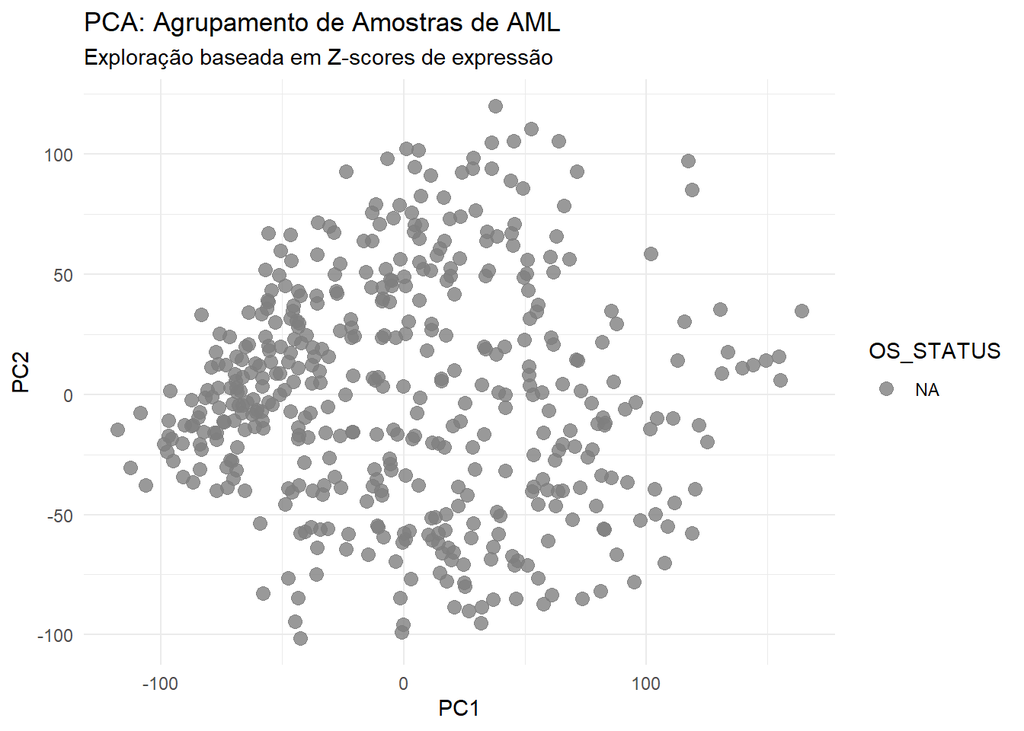

```r
# 3. Exploração com PCA
pca_res <- prcomp(df_num, scale. = TRUE)
pca_data <- as.data.frame(pca_res$x)
pca_data$SAMPLE_ID <- rownames(pca_data)


sample_info <- as.data.frame(read.delim("./aml_ohsu_2018/data_clinical_sample.txt", skip = 4, header = TRUE))
clinica_completa <- left_join(sample_info, patient_info, by = "PATIENT_ID")
viz_data <- left_join(pca_data, clinica_completa, by = "SAMPLE_ID")


viz_data <- left_join(pca_data, patient_info, by = c("SAMPLE_ID" = "PATIENT_ID"))

ggplot(viz_data, aes(x=PC1, y=PC2, color=OS_STATUS)) +
  geom_point(size=3, alpha=0.8) +
  theme_minimal() +
  labs(title = "PCA: Agrupamento de Amostras de AML",
       subtitle = "Exploração baseada em Z-scores de expressão")
```

```r
clinica_completa <- read.delim("./aml_ohsu_2018/aml_ohsu_2018_clinical_data.tsv", header = TRUE, check.names = FALSE)

colunas_numericas <- c("Age at Diagnosis", "Bone Marrow Blast Percentage",
                             "WBC", "Platelet count", "Overall Survival (Months)")

summary(clinica_completa[, colunas_numericas])
```

```
##  Age at Diagnosis Bone Marrow Blast Percentage      WBC
##  Min.   : 1.00    Min.   : 0.00                Min.   :  0.100
##  1st Qu.:47.25    1st Qu.:30.00                1st Qu.:  3.667
##  Median :61.00    Median :63.00                Median : 12.835
##  Mean   :57.24    Mean   :55.94                Mean   : 33.174
##  3rd Qu.:71.00    3rd Qu.:83.00                3rd Qu.: 41.212
##  Max.   :87.00    Max.   :98.00                Max.   :459.600
##  NA's   :6        NA's   :213                  NA's   :94
##  Platelet count   Overall Survival (Months)
##  Min.   :  3.00   Min.   :  0.030
##  1st Qu.: 23.00   1st Qu.:  5.545
##  Median : 42.00   Median : 10.660
##  Mean   : 70.13   Mean   : 14.736
##  3rd Qu.: 89.00   3rd Qu.: 18.420
##  Max.   :916.00   Max.   :174.510
##  NA's   :182      NA's   :73
```

```r
table(clinica_completa$`ELN 2017 Risk Classification`)
```

```
##
##                   Adverse                 Favorable Favorable or Intermediate
##                       242                       155                        27
##              Intermediate   Intermediate or Adverse                   Unknown
##                       235                        11                         2
```

```r
table(clinica_completa$`FLT3-ITD Consensus Call`)
```

```
##
## Negative Positive
##      507      163
```

```r
table(clinica_completa$`NPM1 Consensus Call`)
```

```
##
## Negative Positive
##      499      170
```

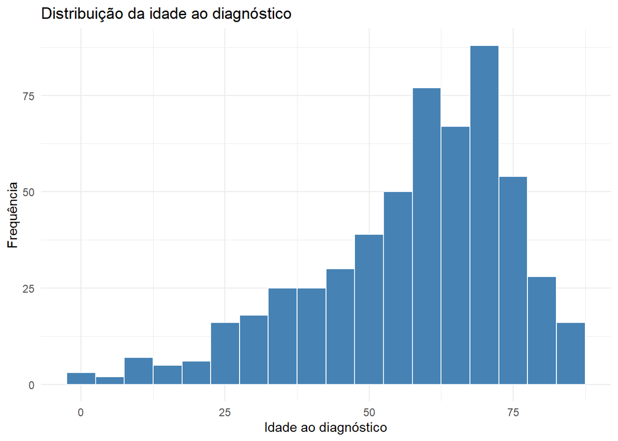

```r
ggplot(patient_info, aes(x = AGE_AT_DIAGNOSIS)) +
  geom_histogram(binwidth = 5, fill = "steelblue", color = "white") +
  theme_minimal() +
  labs(
    title = "Distribuição da idade ao diagnóstico",
    x = "Idade ao diagnóstico",
    y = "Frequência"
  )
```

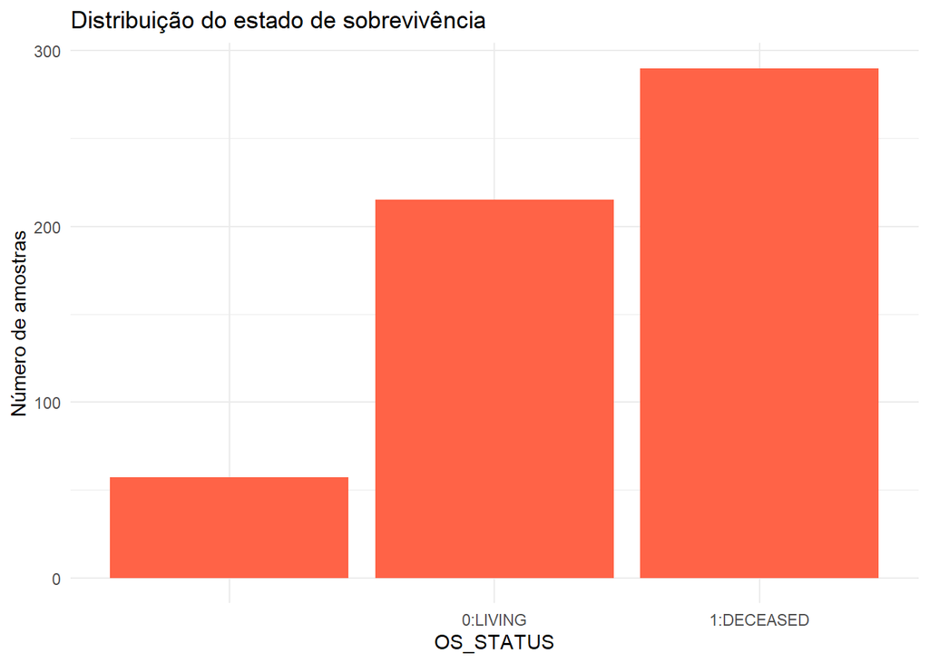

```r
ggplot(patient_info, aes(x = OS_STATUS)) +
  geom_bar(fill = "tomato") +
  theme_minimal() +
  labs(
    title = "Distribuição do estado de sobrevivência",
    x = "OS_STATUS",
    y = "Número de amostras"
  )
```

## **Análise de expressão diferencial e de enriquecimento**

Foi realizada uma análise de expressão diferencial para comparar doentes vivos (**0:LIVING**) e falecidos (**1:DECEASED**). Os dados de expressão genética foram organizados numa matriz e integrados com a informação clínica, garantindo o correto alinhamento entre amostras.

A análise foi conduzida utilizando o pacote *limma* através de um modelo linear (*lmFit*) seguido de moderação empírica (*eBayes*). Os genes diferencialmente expressos foram obtidos com *topTable*.

Considerando um limiar de significância de **adj.P.Val** < 0.05, foram identificados 569 genes diferencialmente expressos entre os dois grupos. Alguns dos genes mais relevantes incluem *TJP2*, *FNDC3B*, *NRIP1* e *CD109*, sugerindo uma possível associação com o estado de sobrevivência.

```r
# expressão: linhas = genes, colunas = amostras
expr_mat <- t(as.matrix(df_num))
mode(expr_mat) <- "numeric"

# IDs das amostras vindos da expressão
expr_ids <- colnames(expr_mat)

# ler sample_info
sample_info <- as.data.frame(read.delim("./aml_ohsu_2018/data_clinical_sample.txt", skip = 4, header = TRUE))

# ver nomes das colunas
colnames(sample_info)
```

```
##  [1] "PATIENT_ID"
##  [2] "SAMPLE_ID"
##  [3] "SAMPLE_TIMEPOINT"
##  [4] "FUSION"
##  [5] "SPECIFIC_DIAGNOSIS_AT_INCLUSION"
##  [6] "ELN_2017"
##  [7] "ELN_2008"
##  [8] "SPECIFIC_DIAGNOSIS_AT_ACQUISITION"
##  [9] "GROUP"
## [10] "SAMPLE_SITE"
## [11] "PLATFORM"
## [12] "RNA_SEQUENCED"
## [13] "WHOLE_EXOME_SEQUENCING"
## [14] "EX_VIVO_DRUG_TESTING"
## [15] "RNA_SEQ_ANALYSIS"
```

[output cut: 60 more lines]

```r
# criar versões normalizadas dos IDs para tentar fazer match
sample_info2 <- sample_info %>%
  mutate(
    SAMPLE_ID_RAW = SAMPLE_ID,
    SAMPLE_ID_A = SAMPLE_ID,
    SAMPLE_ID_B = paste0("aml_ohsu_2018_", SAMPLE_ID),
    SAMPLE_ID_C = gsub("-", ".", SAMPLE_ID),
    SAMPLE_ID_D = paste0("aml_ohsu_2018_", gsub("-", ".", SAMPLE_ID))
  )

# descobrir qual formato bate com a expressão
sum(sample_info2$SAMPLE_ID_A %in% expr_ids)
```

```
## [1] 0
```

```r
sum(sample_info2$SAMPLE_ID_B %in% expr_ids)
```

```
## [1] 0
```

```r
sum(sample_info2$SAMPLE_ID_C %in% expr_ids)
```

```
## [1] 451
```

```r
sum(sample_info2$SAMPLE_ID_D %in% expr_ids)
```

```
## [1] 0
```

```r
# escolher automaticamente o melhor formato
matches <- c(
  A = sum(sample_info2$SAMPLE_ID_A %in% expr_ids),
  B = sum(sample_info2$SAMPLE_ID_B %in% expr_ids),
  C = sum(sample_info2$SAMPLE_ID_C %in% expr_ids),
  D = sum(sample_info2$SAMPLE_ID_D %in% expr_ids)
)

best_format <- names(which.max(matches))
best_format
```

```
## [1] "C"
```

```r
sample_info2$SAMPLE_ID_MATCH <- switch(
  best_format,
  A = sample_info2$SAMPLE_ID_A,
  B = sample_info2$SAMPLE_ID_B,
  C = sample_info2$SAMPLE_ID_C,
  D = sample_info2$SAMPLE_ID_D
)

# juntar com dados clínicos do paciente
dados_deg <- left_join(sample_info2, patient_info, by = "PATIENT_ID")

# manter só amostras presentes na matriz de expressão
dados_deg <- dados_deg %>%
  filter(SAMPLE_ID_MATCH %in% expr_ids)

# manter só grupos válidos
dados_deg <- dados_deg %>%
  filter(!is.na(OS_STATUS),
         OS_STATUS %in% c("0:LIVING", "1:DECEASED"))

# ordenar pela mesma ordem da expressão
dados_deg <- dados_deg %>%
  arrange(match(SAMPLE_ID_MATCH, expr_ids))

# filtrar matriz de expressão
expr_deg <- expr_mat[, dados_deg$SAMPLE_ID_MATCH, drop = FALSE]

# confirmar alinhamento
all(dados_deg$SAMPLE_ID_MATCH == colnames(expr_deg))
```

```
## [1] TRUE
```

```r
# grupo
grupo <- factor(dados_deg$OS_STATUS,
                levels = c("0:LIVING", "1:DECEASED"))

table(grupo)
```

```
## grupo
##   0:LIVING 1:DECEASED
##        170        238
```

```r
# modelo
design <- model.matrix(~ grupo)
fit <- lmFit(expr_deg, design)
fit <- eBayes(fit)

# resultados
res_deg <- topTable(fit, coef = 2, number = Inf)
res_deg$gene <- rownames(res_deg)

sig_deg <- res_deg %>%
  filter(adj.P.Val < 0.05)

head(sig_deg)
```

```
##              logFC       AveExpr         t      P.Value    adj.P.Val         B
## TJP2     0.5950638  0.0410575980  6.132235 1.414444e-09 3.231014e-05 11.206159
## FNDC3B  -0.5379412  0.0009833333 -5.552706 3.931984e-08 3.006274e-04  8.177607
## NRIP1    0.5389316  0.0061955882  5.542676 4.154449e-08 3.006274e-04  8.127602
## CD109    0.5371033 -0.0003438725  5.499352 5.264237e-08 3.006274e-04  7.912540
## EGLN3    0.5309700 -0.0170786765  5.371496 1.048832e-07 4.791694e-04  7.286890
## LRRC16A  0.5151543  0.0178313725  5.233110 2.177001e-07 6.431454e-04  6.624976
##            gene
## TJP2       TJP2
## FNDC3B   FNDC3B
## NRIP1     NRIP1
## CD109     CD109
## EGLN3     EGLN3
## LRRC16A LRRC16A
```

```r
nrow(sig_deg)
```

```
## [1] 569
```